# Expository Data Analysis w/ R - ECOG 314

FRB R Instructors Group

Friday, September 02, 2016

## Lecture 1: Introduction to Basics

```
Filename       Lecture1_version1_8_26_2016

Created on     August 26, 2016
Last revised

References
----------
RStudio      http://dss.princeton.edu/training/RStudio101.pdf
             https://support.rstudio.com/hc/en-us/articles/200404846-Working-in-the-Console

Intro to R   https://cran.r-project.org/doc/manuals/r-release/R-intro.html
```

### Sections

```
1.  Install R and RStudio

1.1   Start RStudio

1.2   Take your first steps with R.

1.3   Explore the features, menus and windows in RStudio

2.  Introduce the basic R data types including vectors, arrays,
    lists, matrices, data frame and factors. Explore basic operations
    on the basic R data types.

3.  Load the mosaic package.

3.1   Use help (?) to examine the summary function.

3.2   Display the functions in the mosaic package
      - Use Google search or ls("package:mosaic")

4.  Comment your work, save your workspace, and exit your R session

5.  In-class Lab Excercises

6.  Homework 1 assigned  (Inserted as Homework Q?)
```

#### 1. Install R and RStudio

- Follow instructions provided in: Lecture1_part1_INSTALLING_R_and_RStudio_your_computer_draft1.pdf

#### 1.1 Start RStudio, take your first steps with R, explore the features, menus and windows in RStudio

- Start RStudio (Windows key, RStudio <Enter>)
- Take your first steps with R
  - Enter the following at the > prompt, one line at time, and press the <Enter> after each line

```r
# R as a calculator
1 + 1
2 + 5

sqrt(25)

x = 2
x + 3

y <- 3                                         # preferred form of variable assignment
y^3

x + y
y <- (x + 1 )^2 ; y


# List of objects created so far
ls()

# plot(1:10, col=1:10, main="First R plot")
```

Inspect the tabs in the top and bottom right panels or windows in your RStudio session

**In the top panel**

- Click on the “Environment” tab and inspect the contents of some of the variables
- Click on the “History” tab to view the history of the commands entered
- Click on a line of text (from the History tab), click on “To Console” to insert the text into a new or current script file
- Select (drag your mouse over) 5 or more lines of text (from the History tab), click on “To Source” to send the command to the R Console
- You may save the history, clear part or all of your history

**In the bottom panel**

- Click on the “Files” tab to view files and folders in your working directory
- Click on the “Packages” tab to view installed packages
- Click on a “Packages” tab to view the help documentation on the package
- Click on the “Plots”to view your current plot
- Click on “Zoom” (from the Plots tab) to detach your plot
- Click on “Export” (from the Plots tab) to export your plot to required format
- Click on “File” (in the Main menu), inspect the menu items
- Click on “Session”, “Set Working Directory”, “Choose Directory”, select a directory, and click on “Select Folder”. Note the command at your prompt
- Click on “Help” and the “RHelp”
- From the “Help” window, click on an “Introduction to R”
- You can also search for a function (sqrt) from the search entry in the “Help” window
- You can also search for text from the help text window

**Console commands**

RStudio supports command completion using the **Tab** key. For example: * Type **sqr** then press the **Tab** key, you should see

```r
sqrt()
```

**Note**: Command completion can be turned on/off through the menu. Click on “Tools” -> “Global Options …” -> “Code” -> “Completion”

Previous commands can either be retrieved from the “History” window or by:

- **Up**/**Down** keys recall previous commands
- **Ctrl-UP** (MAC, *Command-Up*) retrieves a list of recent commands

Enter the following at your R console and press Enter after each line of code

```r
a1 <- 1
a2 <- 3
a4 <- a1 + a2
```

Use the **Up**/**Down** keys to recall previous commands. For a list of commands that begin with the letter **a**, type **a** at the command prompt, then press **Ctrl-UP** (i.e., hold down CTRL key and press and release the up-arrow key).

**Keyboard Shortcuts**

- **Ctrl-1** Moves cursor to Source Editor window
- **Ctrl-2** Moves cursor to the Console window
- **Ctrl-4** Moves cursor to the Console window
- **Esc** Interrupts R
- Additional list of keyboard shortcuts are listed in [here](https://support.rstudio.com/hc/en-us/articles/200711853)

### New R Script file

**Outside RStudio**

- Create an **ECOG_314** folder on your desktop
- Create a **lecture_1** sub-folder in the **ECOG_314** folder

**In RStudio**

- Point your **Working directory** to the **ECOG_314/lecture_1** folder on your desktop: Session -> Set Working Directory -> Choose Directory …
- Create a new R script file: File -> New File -> R Script

#### Entering Data

R functions/operators we will be using

- `<-` and `=` assignment operator
- `+`, `-`, `*`, `^` arithmetic operators
- `[ ]` sub-setting
- `c()` create a vector
- `cbind()` combine them into a n x 2 matrix
- `list()` create an ordered collection of values
- `matrix()` create a matrix
- `dataframe()` create a dateframe
- `head()` show first few rows of data object
- `seq()` create sequence
- `tail()` show last few rows of data object
- `min()`, `max()`, `mean()`, `median()`, `mode()` general stats on on object
- `summary()` shows a summary of data object
- `typeof()` displays an object type
- `class()` displays the class of an object
- `ls()` list objects
- `rm()` remove object
- Extras – lapply, rep, str, rownames, columnames, make.names

**A quick preview of well used data types**

```r
x <- c(1,2,3,4,5 )                           #create a data vector with specified elements
x2 <- x^2
x3 <- x^3
y <- c(1:10)                                 #create a data vector with elements 1-10
y2 <- y^2

workshop <- c(1, 2, 1, 2, 1, 2, 1, 2)
workshop[c(3, 4)]

z <- letters[c(3, 15, 15, 12, 4, 15, 7)]
z

myVector <- c(10, 20, NA, NA, 50, 60)
mean(myVector)                                 # missing data

mean(myVector, na.rm=TRUE)                     #ignore missing data
(10 + 20 + 50 + 60)/4

q1 <- 1:6
myVector + q1                                  #pair-wise sum
sqrt(q1)
table(myVector)
sum(myVector)
sum(myVector, na.rm=TRUE)
# cumsum(myVector, na.exclude)                 #we will learn ways to resolve the effect of N later


odd_vals <- c(1, 3, 5, 7, 9)
subset(x,odd_vals)                           #those objects meeting a logical criterion

x_df <- data.frame(x=x, x2=x2, x3=x3)       #create another data type

mylist <- list(fname="John", lname="Doe", age=23, height=6.4, sex="M" )
class(mylist)
mylist['lname']
mylist[['lname']]                              #will talk about this later in the course
mylist$lname

q1 <- 1:6
q2 <- 2*q1
q3 <- 3*q1
q4 <- 4*q1
qmat <- cbind(q1, q2, q3, q4)                  #quick way to create a matrix
class(qmat)
dim(qmat)

gender <- c("f", "f", NA, "m", "m", "m")
gender
typeof(gender)
gender[3]
gender[gender != 'f']


head(state.x77)
tail(state.x77)
length(state.x77)
state.x77[c(2,4),]

head(state.abb)
tail(state.abb)
length(state.abb)
state.abb[4:6]

x <- c(1,2,3,4,5 );                          #create a data vector with specified elements
x2 <- x+2
x3 <- x+33
x_vect <- c(x, x2)                           #combine them into one vector of length 2n = 10
x_mat <- cbind(x, x2)                        #combine them into a n x 2 matrix
x_mat[4,2]                                   #display the 4th row and the 2nd column
x_mat[3,]                                    #display the 3rd row
x_mat[,2]                                    #display the 2nd column

A <- matrix(1:15, nrow=5)                    #another matrix
A

( B <- matrix(1:15, nrow=5, byrow = TRUE) )  #Assign and echo

getwd()                                      #the current directory accessible to R on your system
```

### R Basic Data Types

Now that we are familiar with R, we are going to look at the variable types that can be created in R

Note: Be mindful when creating variable names. **Symantically valid** variable names will be covered under Homeworks Q4 and Q5 in this lecture.

#### Vectors

A vector is the most basic data structure in R. All values are vectors. Even scalars are vectors of length 1, called atomic vectors in R.

##### Numeric (integer or double)

```r
value <- 1801           #integer
value
```

```
## [1] 1801
```

```r
myPi <- 3.14            #double
myPi
```

```
## [1] 3.14
```

```r
# internal pi
pi
```

```
## [1] 3.141593
```

```r
#lets verify
typeof(value);                        #what is happening here, I need an integer
```

```
## [1] "double"
```

```r
value2 <- as.integer(value)           #cool thing with R you can always get what you want
typeof(value2)
```

```
## [1] "integer"
```

```r
#
lapply(c(value, myPi, pi), typeof )   #see the class of each of the variables
```

```
## [[1]]
## [1] "double"
##
## [[2]]
## [1] "double"
##
## [[3]]
## [1] "double"
```

```r
lapply(c(value, myPi, pi), class )    #see the class of each of the variables
```

```
## [[1]]
## [1] "numeric"
##
## [[2]]
## [1] "numeric"
##
## [[3]]
## [1] "numeric"
```

##### Character

```r
string <- "FRB 1801 K-Street"
string
```

```
## [1] "FRB 1801 K-Street"
```

```r
class(string); typeof(string)
```

```
## [1] "character"
```

```
## [1] "character"
```

##### Logical

```r
t <-  2 < 4
t
```

```
## [1] TRUE
```

```r
class(t); typeof(t)
```

```
## [1] "logical"
```

```
## [1] "logical"
```

##### Complex

```r
z = 1 + 5i     # create a complex number
z
```

```
## [1] 1+5i
```

```r
class(z); typeof(z)
```

```
## [1] "complex"
```

```
## [1] "complex"
```

##### Factors

Factors (categorical data) and dates are built on top of integers

```r
x <- factor( c("Yes", "No", "No", "Yes", "Yes", "Maybe") )
x
```

```
## [1] Yes   No    No    Yes   Yes   Maybe
## Levels: Maybe No Yes
```

```r
class(x); typeof(x); length(x)
```

```
## [1] "factor"
```

```
## [1] "integer"
```

```
## [1] 6
```

```r
s <-  factor( rep(c("Male", "Female"), times=c(3, 4)) )
s
```

```
## [1] Male   Male   Male   Female Female Female Female
## Levels: Female Male
```

```r
class(s); typeof(s); length(s)
```

```
## [1] "factor"
```

```
## [1] "integer"
```

```
## [1] 7
```

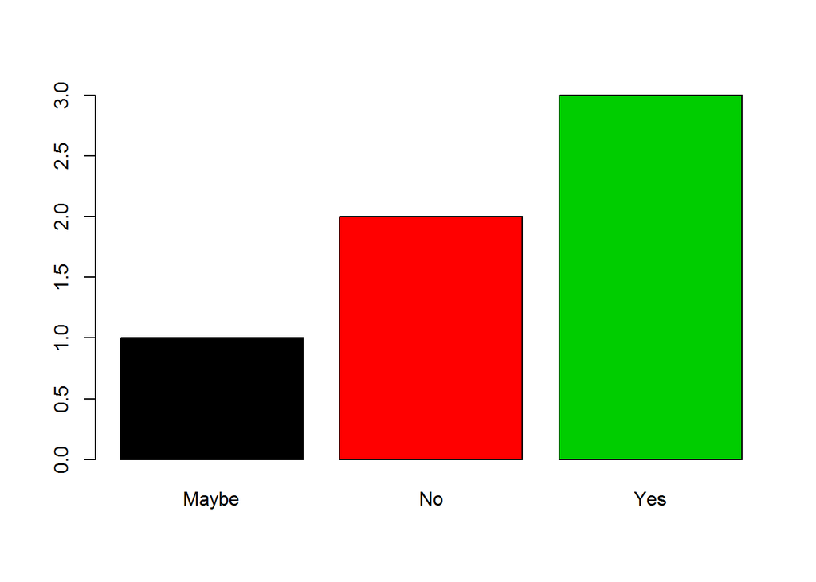

```r
#A quick view
plot(x, col=1:3)                 # new function to demontrate the use of categorical data types
```

```r
#qplot(x)                        # new function
```

# Homeworks Q1 and Q2

#### (2) Lists, sometimes called recursive vectors because lists can contain other lists (the main difference between atomic vectors and lists).

Lists are fundamentally richer than atomic vectors, because they can contain other lists, making them suitable for representing hierarchical or tree-like structures. You create a list with `list()`

```r
xList <- list(1, 2, 3)
yList <- list( class_xlist=class(xList), typeof_xList=typeof(xList), length_xList = length(x) )
yList
```

```
## $class_xlist
## [1] "list"
##
## $typeof_xList
## [1] "list"
##
## $length_xList
## [1] 6
```

```r
str(xList)                       # homework, a new function
```

```
## List of 3
##  $ : num 1
##  $ : num 2
##  $ : num 3
```

```r
str(yList)
```

```
## List of 3
##  $ class_xlist : chr "list"
##  $ typeof_xList: chr "list"
##  $ length_xList: int 6
```

```r
# Homework Q2
# What happens when we add different data types to a vector?

v = c("a","b",1,2,3,TRUE)
```

#### (3) Matrix, a collection of data elements arranged in a two-dimensional rectangular layout.

The data elements of a matrix must be of the same basic type.

```r
 A = matrix(
   c(1:12),            # the data elements
   nrow=3,             # number of rows
   ncol=4,             # number of columns
   byrow = TRUE        # fill matrix by rows
   )
#

A                      # print A
```

```
##      [,1] [,2] [,3] [,4]
## [1,]    1    2    3    4
## [2,]    5    6    7    8
## [3,]    9   10   11   12
```

An element at the mth row, nth column of A can be accessed by the expression A[m, n].

```r
A[3, 1]         # element at 3rd row, 1st column
```

```
## [1] 9
```

```r
A[1,  ]         # all elements of the first row
```

```
## [1] 1 2 3 4
```

```r
A[ , 2]         # second column elements
```

```
## [1]  2  6 10
```

We can also extract multiple rows or columns at a time.

```r
A[ ,c(1,4)]   # the 1st and 4th columns
```

```
##      [,1] [,2]
## [1,]    1    4
## [2,]    5    8
## [3,]    9   12
```

# Homeworks Q3

If we assign names to the rows and columns of the matrix, than we can access the elements by name.

```r
rownames(A)  = c("row_1", "row_2", "row_3")            # row names
colnames(A) = c("col_1", "col_2", "col_3", "col_4")   # column names

# Alternatively
# dimnames(A) = list(
#    c("row_1", "row_2", "row_3"),           # row names
#    c("col_1", "col_2", "col_3", "col_4")   # column names
# )

A                                           # print A
```

```
##       col_1 col_2 col_3 col_4
## row_1     1     2     3     4
## row_2     5     6     7     8
## row_3     9    10    11    12
```

```r
#
class(A); typeof(A); dim(A); length(A)
```

```
## [1] "matrix"
```

```
## [1] "integer"
```

```
## [1] 3 4
```

```
## [1] 12
```

```r
A["row_2", "col_4"]                        # element at 2nd row, 4th column
```

```
## [1] 8
```

```r
#-
# Homework Q.3
B = A
# B[1,1] = 22.9                           # is this permitted? Why?
# B[1,1] = integer part of 22.9           # get this assignment to work
```

#### A data frame is used for storing data tables.

A data frame is a list of vectors of equal length. For example, the following variable df is a data frame containing three vectors a, b, c.

```r
a = 1:3                            #same as c(1, 2, 3) or seq(from=1, to=3, by=1)
b = c("aa", "bb", "cc")            # 3 character sets
c = c(TRUE, FALSE, TRUE)           # 3 logic values

mydf = data.frame(a, b, c)         # mydf is a data frame

head(mydf, n=2)
```

```
##   a  b     c
## 1 1 aa  TRUE
## 2 2 bb FALSE
```

```r
class(mydf); typeof(mydf); dim(mydf)
```

```
## [1] "data.frame"
```

```
## [1] "list"
```

```
## [1] 3 3
```

**Built-in Data Frame**

R has a number of built-in data frames, for example, here is a built-in data frame in R, called mtcars.

```r
head(mtcars)
```

```
##                    mpg cyl disp  hp drat    wt  qsec vs am gear carb
## Mazda RX4         21.0   6  160 110 3.90 2.620 16.46  0  1    4    4
## Mazda RX4 Wag     21.0   6  160 110 3.90 2.875 17.02  0  1    4    4
## Datsun 710        22.8   4  108  93 3.85 2.320 18.61  1  1    4    1
## Hornet 4 Drive    21.4   6  258 110 3.08 3.215 19.44  1  0    3    1
## Hornet Sportabout 18.7   8  360 175 3.15 3.440 17.02  0  0    3    2
## Valiant           18.1   6  225 105 2.76 3.460 20.22  1  0    3    1
```

**Data frame slicing using Numeric Indexing**

To display the cell value from the first row, second column of mtcars.

```r
mtcars[1, 2]
```

```
## [1] 6
```

**Data frame slicing using Name Indexing**

Moreover, we can use the row and column names instead of the numeric coordinates.

```r
mtcars["Mazda RX4", "cyl"]
```

```
## [1] 6
```

**Data frame slicing using Logical Indexing**

finally, we can also retrieve rows with a logical index vector

```r
G = mtcars$gear == 3              #[,10]     gear    Number of forward gears
head( mtcars[G, ] )
```

```
##                    mpg cyl  disp  hp drat    wt  qsec vs am gear carb
## Hornet 4 Drive    21.4   6 258.0 110 3.08 3.215 19.44  1  0    3    1
## Hornet Sportabout 18.7   8 360.0 175 3.15 3.440 17.02  0  0    3    2
## Valiant           18.1   6 225.0 105 2.76 3.460 20.22  1  0    3    1
## Duster 360        14.3   8 360.0 245 3.21 3.570 15.84  0  0    3    4
## Merc 450SE        16.4   8 275.8 180 3.07 4.070 17.40  0  0    3    3
## Merc 450SL        17.3   8 275.8 180 3.07 3.730 17.60  0  0    3    3
```

# Homeworks Q4 and Q5a and 5b

Further details for the mtcars data set are available in the R documentation.

```r
#summary(mtcars)                    #Homework Q4
# help(mtcars)                      #Homework Q5.a

# Homework Q5
# List 3 more built-in data frames available in R
```

#### R Variable names

A **syntactically valid name** consists of letters, numbers and the dot or underline characters and starts with a letter or the dot not followed by a number. Names such as “.2way” are not valid, and neither are the reserved words.

R’s **make.names()** function can be used to check and/or create valid variable names

```r
# ?make.names
make.names(c(".2pi"))
```

```
## [1] "X.2pi"
```

#### The Mosaic package

The mosaic package is designed to help simplify the interface for R users, while allowing them to undertake sophisticated statistical analyses.

```r
#install.packages("mosaic")
library(mosaic)
options(digits=3)

( x <- 1:10 )
( xmean <- mean(x) )                #new (x <- 1)   # assign and display
( xsd <- sd(x) )

# display functions in this package
ls("package:mosaic")

#
#help(mosaic)                    #Homework Q5.b

# Use the summary function
summary()
```

# Homework Q6

- Data from Washington post article Brigid Schulte, 2013, [“**Who U.S.-born children are living with**”](https://www.washingtonpost.com/local/2013/09/10/9c72c1d2-1a6c-11e3-8685-5021e0c41964_graphic.html), a headline from the following article [“**Children suffer from growing economic inequality among families since recession**”](http://www.washingtonpost.com/local/children-suffer-from-growing-economic-inequality-among-families-since-recession/2013/09/10/793423ae-1a4f-11e3-82ef-a059e54c49d0_story.html)
- Aim is to manually input and represent the visualization data in R. We will then learn ways to simplify later in the course.
- Goal is to help students start thinking about midterm project

**Task**

Used R’s `c()` function to create a vector with the following 24 values:

22 50 8 2 13 6 5 24 13 24 20 15 21 33 9 7 20 9 24 53 4 1 12 5

Use: `?c` to determine how the 24 values should be formatted as arguments to `c()`.

Hint: Function arguments are separated by commas.

# Homework Q7

Restructure the vector dat of length 24 into a matrix with 6 rows and hence 4 rows. By default matrix(data=dat, nrow=6) will use the first 6 elements of vector dat as the row values in the first column, the next 6 elements as the row values of the second column and so on for subsequent columns.

Note many people prefer to enter data in Excel and read such files into R. We will use this approach in our next set of lectures

# Homework Q8

A systematic approach helps when it comes to correctly labeling the values.

For this question, use the following as the row and column names for the resulting matrix:

```r
###DO NOT RUN.  This is Q8, You must Fix this segment to run
type <- "Married, Father Working", "Married, Both Working",
           "Divorced Mother","Never-married Mother",
          "Other", "Grandparents"

race <- "White", "Black", "Hispanic", "Asian"
### end of fix to run

rownames(mat) <- type
colnames(mat) <- race
mat
```

# Homework Q9

Install and load the “lattice” package, and use the rDot plots with lines to the origin.

```r
#  Homework Q9:  Uncomment the following 2 lines of text to install the lattice plotting

# install.packages("lattice")
# library(lattice)

dotplot(mat,groups=FALSE,
  layout=c(1,4),aspect=.7,
  origin=0,type=c("p","h"),
  main="Who is Raising the Children?",
  xlab="Rounded Percents\nRace Totals Close To 100",
  scales=list(x=list(tck=0, alternating=FALSE)),
  panel=function(...){
    panel.fill(rgb(.9,.9,.9))
    panel.grid(h=0,v=-1,col="white",lwd=2)
    panel.dotplot(col=rgb(0,.5,1),cex=.9,...)
  }
)
```

# Homework Q10

- Use the help feature in R to display the version of R you are running
- Document your script file by adding text to explain your work.
- Save your history in a file and store in in your lecture_1 folder
- Exit from RStudio
- Upload your script file and its output and to blackboard or mail it to your instructor with a copy to wampeh@frb.gov and andrew.cohen@frb.gov